# **A Process to Analyze and Predict Credit Card Customer Attrition**

*by Rohit Nutalapati*

# 1. Introduction

To finance and banking, the future is everything. More specifically, analyzing the past to understand the future is everything. One of the biggest problems faced by companies in the modern world is the problem of customer attrition. Credit card customer acquisition costs around $200 per user in the United States on average ([source](https://medium.com/unifimoney/changing-the-vicious-cycle-of-push-to-pull-in-customer-acquisition-6218c8644000#:~:text=It%20costs%20on%20average%20around,World%20Elite%20and%20Visa%20Infinite)), and in some cases it can go much higher. Building a loyal customer base secures revenue, and being able to identify customers that are about to attrite enables a company to be able to strengthen their relationship with their customer and incentivizing them to stay.

### Objective

In this tutorial, I will aim to take the reader through the data science pipeline with a customer churn use case. We will explore the factors that result in credit card customer attrition through data analysis as well as machine learning, with a later focus on explainable ML.

Given a dataset with information from customers' bank and transaction records, we want to be able to build an ML model that can predict if a customer is likely to attrite.

# 2. Data Collection and Storage

The dataset is a set of credit card customer records for an unnamed bank (as most are in publicly available financial datasets). The original source of this data is from a website called [LEAPS](https://leapsapp.analyttica.com/cases/11), which has a walkthrough of using naive bayes classification to solve this problem. However, we will be removing the naive bayes columns from the dataset, because the focus of this data science tutorial is on exploratory data analysis and machine learning.

The dataset can be found and downloaded on [Kaggle](https://www.kaggle.com/sakshigoyal7/credit-card-customers), as well.

```python
import numpy as np
import pandas as pd
import seaborn as sns
import matplotlib.pyplot as plt
```

I'm uploading the dataset as a .csv file stored on my local system into this notebook.

```python
from google.colab import files
my_file = files.upload()
```

Upload widget is only available when the cell has been executed in the current browser session. Please rerun this cell to enable.

```
Saving BankChurners.csv to BankChurners.csv
```

Let's take a look at the dataset by storing it in a Pandas DataFrame, `df`.

```python
df = pd.read_csv("BankChurners.csv")
df.head()
```

|  | CLIENTNUM | Attrition_Flag | Customer_Age | Gender | Dependent_count | Education_Level | Marital_Status | Income_Category | Card_Category | Months_on_book | Total_Relationship_Count | Months_Inactive_12_mon | Contacts_Count_12_mon | Credit_Limit | Total_Revolving_Bal | Avg_Open_To_Buy | Total_Amt_Chng_Q4_Q1 | Total_Trans_Amt | Total_Trans_Ct | Total_Ct_Chng_Q4_Q1 | Avg_Utilization_Ratio | Naive_Bayes_Classifier_Attrition_Flag_Card_Category_Contacts_Count_12_mon_Dependent_count_Education_Level_Months_Inactive_12_mon_1 | Naive_Bayes_Classifier_Attrition_Flag_Card_Category_Contacts_Count_12_mon_Dependent_count_Education_Level_Months_Inactive_12_mon_2 |
| --- | --- | --- | --- | --- | --- | --- | --- | --- | --- | --- | --- | --- | --- | --- | --- | --- | --- | --- | --- | --- | --- | --- | --- |
| 0 | 768805383 | Existing Customer | 45 | M | 3 | High School | Married | $60K - $80K | Blue | 39 | 5 | 1 | 3 | 12691.0 | 777 | 11914.0 | 1.335 | 1144 | 42 | 1.625 | 0.061 | 0.000093 | 0.99991 |
| 1 | 818770008 | Existing Customer | 49 | F | 5 | Graduate | Single | Less than $40K | Blue | 44 | 6 | 1 | 2 | 8256.0 | 864 | 7392.0 | 1.541 | 1291 | 33 | 3.714 | 0.105 | 0.000057 | 0.99994 |
| 2 | 713982108 | Existing Customer | 51 | M | 3 | Graduate | Married | $80K - $120K | Blue | 36 | 4 | 1 | 0 | 3418.0 | 0 | 3418.0 | 2.594 | 1887 | 20 | 2.333 | 0.000 | 0.000021 | 0.99998 |
| 3 | 769911858 | Existing Customer | 40 | F | 4 | High School | Unknown | Less than $40K | Blue | 34 | 3 | 4 | 1 | 3313.0 | 2517 | 796.0 | 1.405 | 1171 | 20 | 2.333 | 0.760 | 0.000134 | 0.99987 |
| 4 | 709106358 | Existing Customer | 40 | M | 3 | Uneducated | Married | $60K - $80K | Blue | 21 | 5 | 1 | 0 | 4716.0 | 0 | 4716.0 | 2.175 | 816 | 28 | 2.500 | 0.000 | 0.000022 | 0.99998 |

Right off the bat, we notice three columns (`CLIENTNUM` and the two columns with naive bayes results) that will not serve any purpose in this tutorial. Keeping those around will simply induce a headache until the **Feature Engineering** step in **5. Machine Learning**, so we can remove these three columns straight away.

```python
df.drop(columns=["CLIENTNUM", "Naive_Bayes_Classifier_Attrition_Flag_Card_Category_Contacts_Count_12_mon_Dependent_count_Education_Level_Months_Inactive_12_mon_1","Naive_Bayes_Classifier_Attrition_Flag_Card_Category_Contacts_Count_12_mon_Dependent_count_Education_Level_Months_Inactive_12_mon_2"], inplace=True)
df.head()
```

|  | Attrition_Flag | Customer_Age | Gender | Dependent_count | Education_Level | Marital_Status | Income_Category | Card_Category | Months_on_book | Total_Relationship_Count | Months_Inactive_12_mon | Contacts_Count_12_mon | Credit_Limit | Total_Revolving_Bal | Avg_Open_To_Buy | Total_Amt_Chng_Q4_Q1 | Total_Trans_Amt | Total_Trans_Ct | Total_Ct_Chng_Q4_Q1 | Avg_Utilization_Ratio |
| --- | --- | --- | --- | --- | --- | --- | --- | --- | --- | --- | --- | --- | --- | --- | --- | --- | --- | --- | --- | --- |
| 0 | Existing Customer | 45 | M | 3 | High School | Married | $60K - $80K | Blue | 39 | 5 | 1 | 3 | 12691.0 | 777 | 11914.0 | 1.335 | 1144 | 42 | 1.625 | 0.061 |
| 1 | Existing Customer | 49 | F | 5 | Graduate | Single | Less than $40K | Blue | 44 | 6 | 1 | 2 | 8256.0 | 864 | 7392.0 | 1.541 | 1291 | 33 | 3.714 | 0.105 |
| 2 | Existing Customer | 51 | M | 3 | Graduate | Married | $80K - $120K | Blue | 36 | 4 | 1 | 0 | 3418.0 | 0 | 3418.0 | 2.594 | 1887 | 20 | 2.333 | 0.000 |
| 3 | Existing Customer | 40 | F | 4 | High School | Unknown | Less than $40K | Blue | 34 | 3 | 4 | 1 | 3313.0 | 2517 | 796.0 | 1.405 | 1171 | 20 | 2.333 | 0.760 |
| 4 | Existing Customer | 40 | M | 3 | Uneducated | Married | $60K - $80K | Blue | 21 | 5 | 1 | 0 | 4716.0 | 0 | 4716.0 | 2.175 | 816 | 28 | 2.500 | 0.000 |

# 3. Data Representation

Let's see what Pandas can reveal to us about the size and the data types of the entries in each column, and then cross-reference that with the descriptions from the original source to identify which variables are numerical ones and which are categorical ones, and then list out what they each mean.

```python
df.shape
```

```
(10127, 20)
```

```python
df.dtypes
```

```
Attrition_Flag               object
Customer_Age                  int64
Gender                       object
Dependent_count               int64
Education_Level              object
Marital_Status               object
Income_Category              object
Card_Category                object
Months_on_book                int64
Total_Relationship_Count      int64
Months_Inactive_12_mon        int64
Contacts_Count_12_mon         int64
Credit_Limit                float64
Total_Revolving_Bal           int64
Avg_Open_To_Buy             float64
Total_Amt_Chng_Q4_Q1        float64
Total_Trans_Amt               int64
Total_Trans_Ct                int64
Total_Ct_Chng_Q4_Q1         float64
Avg_Utilization_Ratio       float64
dtype: object
```

Now, below is a breakdown of the numerical and the categorial variables along with corresponding descriptions as listed on the original source, LEAPS.

Numerical Variables:

- `Customer_Age`: Demographic variable - Customer's Age in Years
- `Dependent_count`: Demographic variable - Number of dependents
- `Months_on_book`: Months on book (Time of Relationship)
- `Total_Relationship_Count`: Total no. of products held by the customer
- `Months_Inactive_12_mon`: No. of months inactive in the last 12 months
- `Contacts_Count_12_mon`: No. of Contacts in the last 12 months
- `Credit_Limit`: Credit Limit on the Credit Card
- `Total_Revolving_Bal`: Total Revolving Balance on the Credit Card
- `Avg_Open_To_Buy`: Open to Buy Credit Line (Average of last 12 months)
- `Total_Amt_Chng_Q4_Q1`: Change in Transaction Amount (Q4 over Q1)
- `Total_Trans_Amt`: Total Transaction Amount (Last 12 months)
- `Total_Trans_Ct`: Total Transaction Count (Last 12 months)
- `Total_Ct_Chng_Q4_Q1`: Change in Transaction Count (Q4 over Q1)
- `Avg_Utilization_Ratio`: Average Card Utilization Ratio

Catergorical Variables:

- `Attrition_Flag`: Internal event (customer activity) variable - if the account is closed then 1 else 0
- `Gender`: Demographic variable - M=Male, F=Female
- `Education_Level`: Demographic variable - Educational Qualification of the account holder
- `Marital_Status`: Demographic variable - Married, Single, Unknown
- `Income_Category`: Demographic variable - Annual Income Category of the account holder
- `Card_Category`: Product Variable - Type of Card (Blue, Silver, Gold, Platinum)

### Target Variable

Our target variable here, the one that we will focus our analysis around, is `Attrition_Flag`, according to the goal set forth in **1. Introduction**.

### Missing Data

There's another problem that's immediately visible when we examine the output of `df.head()`, which is the presence of rows with "Unknown" values. This dataset does have some missing data. Since we do not have too much information about how the data was collected, attempting to fill in these values with mean values, mode values, or some other form of extrapolation might not present us with an accurate enough picture.

It is most likely best to remove rows with "Unknown" values from the dataset since the data we have will eventually be used in ML further below.

```python
for i in df.columns: # get a list of all the columns in df_cln so that we can iterate over them
  df = df[df[i] != "Unknown"] # and keeping only the rows that have no "Unknown" values
df.shape
```

```
(7081, 20)
```

Fortunately, we only lost approximately 30% of the dataset to missing data, which still leaves us plenty to analyze.

### Unique Values

With the missing data gone, let's now see how many unique values each feature holds.

```python
pd.concat([df.nunique()], axis= 1).rename(columns={0:'Unique_Values'}).sort_values('Unique_Values')
```

|  | Unique_Values |
| --- | --- |
| Attrition_Flag | 2 |
| Gender | 2 |
| Marital_Status | 3 |
| Card_Category | 4 |
| Income_Category | 5 |
| Total_Relationship_Count | 6 |
| Dependent_count | 6 |
| Education_Level | 6 |
| Months_Inactive_12_mon | 7 |
| Contacts_Count_12_mon | 7 |
| Months_on_book | 44 |
| Customer_Age | 45 |
| Total_Trans_Ct | 124 |
| Total_Ct_Chng_Q4_Q1 | 771 |
| Avg_Utilization_Ratio | 946 |
| Total_Amt_Chng_Q4_Q1 | 1067 |
| Total_Revolving_Bal | 1821 |
| Total_Trans_Amt | 4194 |
| Credit_Limit | 4654 |
| Avg_Open_To_Buy | 5144 |

It seems like all of the categorical variables we identified in organizing our initial list have low counts of unique values, which is great since it would be hard to make sense of categorical variables that could take on a wide range of values - they may as well be continuous beyond a point. We can also rest assured that our focus, `Attrition_Flag`, only has two unique values. Phew!

# 4. Exploratory Data Analysis

Now that we've been able to organize our understanding of the features we have in the dataset, let's look at some key relationships between the variables that can help inform our judgement as to what affects credit card customer attrition.

### Balance

A good starting point would be to check the balance of the dataset and see what proportion of our data represents customers that actually attrited.

```python
df.Attrition_Flag.value_counts()
```

```
Existing Customer    5968
Attrited Customer    1113
Name: Attrition_Flag, dtype: int64
```

This is a very imbalanced dataset, with only about 16% who attrited!

### Spread of Data

Let's get some stats about each of the numerical columns in our dataset, and see what we can learn from that.

```python
df.describe().apply(lambda s: s.apply('{0:.3f}'.format))
```

|  | Customer_Age | Dependent_count | Months_on_book | Total_Relationship_Count | Months_Inactive_12_mon | Contacts_Count_12_mon | Credit_Limit | Total_Revolving_Bal | Avg_Open_To_Buy | Total_Amt_Chng_Q4_Q1 | Total_Trans_Amt | Total_Trans_Ct | Total_Ct_Chng_Q4_Q1 | Avg_Utilization_Ratio |
| --- | --- | --- | --- | --- | --- | --- | --- | --- | --- | --- | --- | --- | --- | --- |
| count | 7081.000 | 7081.000 | 7081.000 | 7081.000 | 7081.000 | 7081.000 | 7081.000 | 7081.000 | 7081.000 | 7081.000 | 7081.000 | 7081.000 | 7081.000 | 7081.000 |
| mean | 46.348 | 2.338 | 35.981 | 3.819 | 2.343 | 2.454 | 8492.774 | 1167.502 | 7325.272 | 0.761 | 4394.300 | 64.503 | 0.712 | 0.282 |
| std | 8.041 | 1.292 | 8.003 | 1.544 | 0.995 | 1.105 | 9126.073 | 812.316 | 9131.218 | 0.223 | 3468.462 | 23.809 | 0.239 | 0.279 |
| min | 26.000 | 0.000 | 13.000 | 1.000 | 0.000 | 0.000 | 1438.300 | 0.000 | 3.000 | 0.000 | 510.000 | 10.000 | 0.000 | 0.000 |
| 25% | 41.000 | 1.000 | 31.000 | 3.000 | 2.000 | 2.000 | 2498.000 | 463.000 | 1248.000 | 0.629 | 2089.000 | 44.000 | 0.583 | 0.026 |
| 50% | 46.000 | 2.000 | 36.000 | 4.000 | 2.000 | 2.000 | 4287.000 | 1282.000 | 3250.000 | 0.735 | 3831.000 | 67.000 | 0.700 | 0.186 |
| 75% | 52.000 | 3.000 | 40.000 | 5.000 | 3.000 | 3.000 | 10729.000 | 1781.000 | 9491.000 | 0.858 | 4740.000 | 80.000 | 0.818 | 0.515 |
| max | 73.000 | 5.000 | 56.000 | 6.000 | 6.000 | 6.000 | 34516.000 | 2517.000 | 34516.000 | 3.397 | 17995.000 | 134.000 | 3.714 | 0.999 |

Let's make note of some major observations and potential explanations:

- `Customer_Age` is centered around 46, not dropping below 26 and not exceeding 73. This could indicate that this bank doesn't focus on the lower-age demographic through means like e-banking or a smartphone app (even though those may be options), and there don't seem to be any accounts listed for minors.
- `Dependent_count` shows us most customers have at least two dependents, spanning all the way up to five, which seems fitting given the spread of the customers' ages.
- `Months_on_book` seems to range from accounts that have been open for just over a year to accounts that have been open for about four years. A little unexpected, given that the age range is on the higher side, but perhaps in the data we've been given the bank wanted to focus on the younger accounts which have a naturally higher attrition propensity.
- `Months_Inactive_12_mon` certainly seems like an important feature to retain as a telltale sign of a customer about to churn.
- `Contacts_Count_12_mon` ranges from no contacts to six contacts in the last year. On the surface, this may seem like more contacts is a good thing, since it signals a lack of customer inactivity. However, that's not something to immediately conclude without knowing if the contacts were about, for example, a malfunctioning product.
- Customers with high a `Total_Revolving_Bal` and `Avg_Utilization_Ratio` would probably be more likely to stay.

### Initial Exploration

Let's verify if that last point on the list abovelink text is true by examining violinplots to show us the distributions.

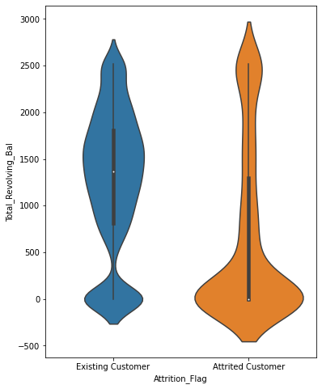

```python
plt.figure(figsize=(6, 8))
sns.violinplot(data=df, x="Attrition_Flag", y="Total_Revolving_Bal")
```

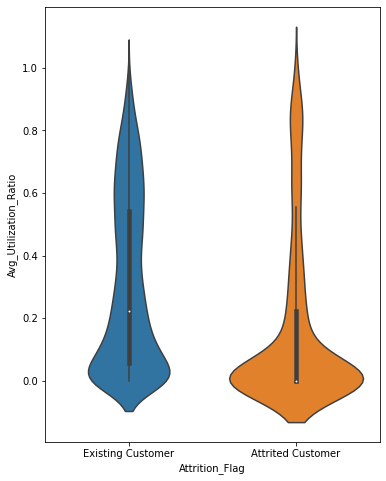

```python
plt.figure(figsize=(6, 8))
sns.violinplot(data=df, x="Attrition_Flag", y="Avg_Utilization_Ratio")
```

It seems that these factors do make a difference, as intended! While we're at it, let's take a look at the difference between the number of products customers have held when they've stayed versus attrited.

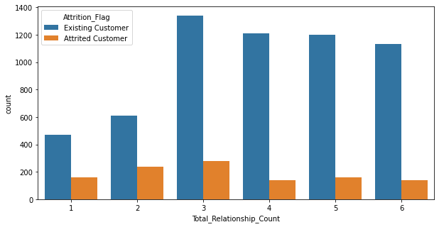

```python
plt.figure(figsize=(10, 5))
sns.countplot(data=df, x="Total_Relationship_Count", hue="Attrition_Flag")
```

This is also a useful piece of information to us! Looking at the relative distributions, customers with more products with the bank are more likely to stay, and those with less products are more likely to attrite.

Intuitively, there should be a link between `Customer_Age` and `Months_on_book`, since older customers would tend to have longer open accounts. Let's examine a scatter plot between those two variables with a regression line.

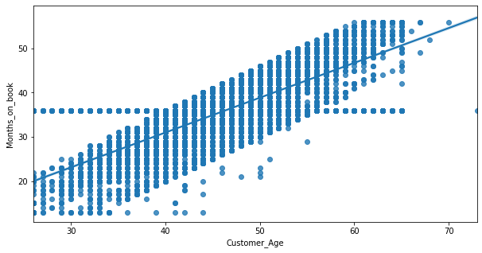

```python
plt.figure(figsize=(10,5))
sns.regplot(data=df, x="Customer_Age", y="Months_on_book")
```

That is a very strong correlation! It does make logical sense for this trend to exist, as previously noted, but this could pose problems when we search for collinearity in our data later on.

Another intriguing aspect of the shape of the scatter plot here is the values of `Months_on_book` centering heavily around a singular value between 30 and 40. Let's examine that distribution.

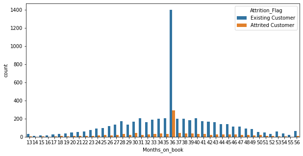

```python
plt.figure(figsize=(10,5))
sns.countplot(data=df, x="Months_on_book", hue="Attrition_Flag")
```

That is such a heavy center of the distribution! While the overall spread looks symmetrical, it's strange that so many of our datapoints lie squarely at 36 months of having an open account with the bank. We don't have too much temporal context about the collection of this data to be able to guess why, but this variable probably would not be doing our ML model too many favors.

Does `Customer_Age`'s effect on `Attrition_Flag` have any surprises in store for us?

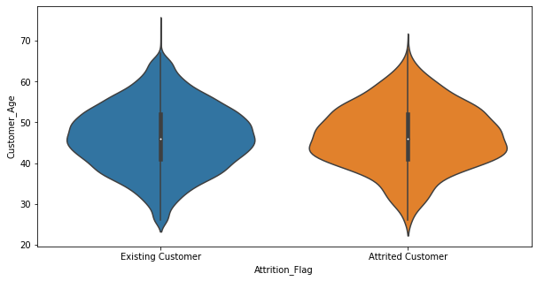

```python
plt.figure(figsize=(10,5))
sns.violinplot(data=df, x="Attrition_Flag", y="Customer_Age")
```

There's barely any difference between the the age distributions of customers who attrited and customers who stayed with the bank! At least, that's what the data we have tells us.

Another factor that we'd think would affect `Attrition_Flag` is `Income_Category`. Examining that distribution could tell us if our little informal hypothesis is accurate.

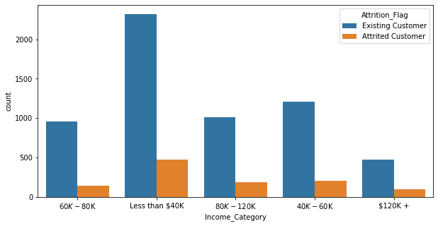

```python
plt.figure(figsize=(10,5))
sns.countplot(x="Income_Category", data=df, hue="Attrition_Flag")
```

Just by eyeballing it, the income category distributions between the existing and the attrited customers don't look all that different. Maybe it doesn't affect `Attrition_Flag` as much as we thought. A more rigorous analysis further below can confirm that.

We've been able to identify some high-level information, examine a couple preliminary distributions, and make some broad observations. However, this is only giving us part of the picture. We need to look at all the features we have at hand and see what we can analyze in terms of both interdependence of the feature set as well as the target variable, `Attrition_Flag`.

### Encoding Categorical Variables

In order for us to be able to assess relationships between our variables further, it would be best to convert the categorical values we have into a numerical form as well for better comparison. Not to mention, ML models don't digest unless they're made into numbers!

Unfortunately, an ordinal encoding may (by definition) introduce some level of unintended ordering in those variables, but the other option is to convert those values into dummy columns (one-hot-encoded), which would be harder to search for correlations in. We'll go ahead and encode them ordinally.

**Note:** `Attrition_Flag` will be encoded such that `0` represents a customer who stayed and `1` represents a customer who attrited, since the problem is focused towards the event of attrition.

```python
categories_encoded = {
                "Attrition_Flag": {"Existing Customer": 0, "Attrited Customer": 1},
                "Gender": {"M": 1, "F": 2},
                "Education_Level": {"Uneducated": 1, "High School": 2, "College": 3, "Graduate": 4, "Post-Graduate": 5, "Doctorate": 6},
                "Marital_Status": {"Single": 1, "Divorced": 2, "Married": 3},
                "Income_Category": {"Less than $40K": 1, "$40K - $60K": 2, "$60K - $80K": 3, "$80K - $120K": 4, "$120K +": 5},
                "Card_Category": {"Blue": 1, "Silver": 2, "Gold": 3, "Platinum": 4}
                }

df.replace(categories_encoded, inplace=True)
df.head()
```

|  | Attrition_Flag | Customer_Age | Gender | Dependent_count | Education_Level | Marital_Status | Income_Category | Card_Category | Months_on_book | Total_Relationship_Count | Months_Inactive_12_mon | Contacts_Count_12_mon | Credit_Limit | Total_Revolving_Bal | Avg_Open_To_Buy | Total_Amt_Chng_Q4_Q1 | Total_Trans_Amt | Total_Trans_Ct | Total_Ct_Chng_Q4_Q1 | Avg_Utilization_Ratio |
| --- | --- | --- | --- | --- | --- | --- | --- | --- | --- | --- | --- | --- | --- | --- | --- | --- | --- | --- | --- | --- |
| 0 | 0 | 45 | 1 | 3 | 2 | 3 | 3 | 1 | 39 | 5 | 1 | 3 | 12691.0 | 777 | 11914.0 | 1.335 | 1144 | 42 | 1.625 | 0.061 |
| 1 | 0 | 49 | 2 | 5 | 4 | 1 | 1 | 1 | 44 | 6 | 1 | 2 | 8256.0 | 864 | 7392.0 | 1.541 | 1291 | 33 | 3.714 | 0.105 |
| 2 | 0 | 51 | 1 | 3 | 4 | 3 | 4 | 1 | 36 | 4 | 1 | 0 | 3418.0 | 0 | 3418.0 | 2.594 | 1887 | 20 | 2.333 | 0.000 |
| 4 | 0 | 40 | 1 | 3 | 1 | 3 | 3 | 1 | 21 | 5 | 1 | 0 | 4716.0 | 0 | 4716.0 | 2.175 | 816 | 28 | 2.500 | 0.000 |
| 5 | 0 | 44 | 1 | 2 | 4 | 3 | 2 | 1 | 36 | 3 | 1 | 2 | 4010.0 | 1247 | 2763.0 | 1.376 | 1088 | 24 | 0.846 | 0.311 |

Fortunately, most of those variables work fine with an ordered encoding! That means that there is a broad level of natural ordering that can be provided to them that makes sense, such as increasing `Education_Level` and increasing `Income_Category`.

The only one that *really* doesn't have an order to it is `Gender`, but we simply have to pick an arbitrary order to continue with analysis. Let's just confirm that we're left with only numerical values in each column before moving onto more advanced EDA.

```python
df.dtypes
```

```
Attrition_Flag                int64
Customer_Age                  int64
Gender                        int64
Dependent_count               int64
Education_Level               int64
Marital_Status                int64
Income_Category               int64
Card_Category                 int64
Months_on_book                int64
Total_Relationship_Count      int64
Months_Inactive_12_mon        int64
Contacts_Count_12_mon         int64
Credit_Limit                float64
Total_Revolving_Bal           int64
Avg_Open_To_Buy             float64
Total_Amt_Chng_Q4_Q1        float64
Total_Trans_Amt               int64
Total_Trans_Ct                int64
Total_Ct_Chng_Q4_Q1         float64
Avg_Utilization_Ratio       float64
dtype: object
```

### Multicollinearity

Multicollinearity is the presence of independent variables that are interrelated to a high degree, making it difficult to distinguish their individual effects on the target variable.

In our case, we want to identify which of our features contribute to multicollinearity so that we can make it easier for our ML model coming in later to distinguish between these factors in predicting if a customer will attrite.

From the initial analysis, it does seem like the exact relation between attrition and most major features is hard to pinpoint. Let us use VIF (Variance Inflation Factor) as a way to measure which variables are contributing most to multicollinearity.

VIF is given by the formula:

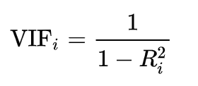

where R^2 is the coefficient of determination in linear regression. This is what makes VIF a good way to detect collinearity amongst variables. A VIF value much larger than 10 is best avoided.

```python
from statsmodels.stats.outliers_influence import variance_inflation_factor

vif_independent_vars = df.iloc[:, 1:18] # separating out the feature set

vif_data = pd.DataFrame()
vif_data["Feature"] = vif_independent_vars.columns
vif_data["VIF"] = [variance_inflation_factor(vif_independent_vars.values, i) for i in range(len(vif_independent_vars.columns))]
vif_data
```

|  | Feature | VIF |
| --- | --- | --- |
| 0 | Customer_Age | 84.666054 |
| 1 | Gender | 18.885704 |
| 2 | Dependent_count | 4.356983 |
| 3 | Education_Level | 5.594990 |
| 4 | Marital_Status | 5.831999 |
| 5 | Income_Category | 10.051182 |
| 6 | Card_Category | 15.296336 |
| 7 | Months_on_book | 56.933513 |
| 8 | Total_Relationship_Count | 7.766398 |
| 9 | Months_Inactive_12_mon | 6.379486 |
| 10 | Contacts_Count_12_mon | 5.739126 |
| 11 | Credit_Limit | inf |
| 12 | Total_Revolving_Bal | inf |
| 13 | Avg_Open_To_Buy | inf |
| 14 | Total_Amt_Chng_Q4_Q1 | 11.654772 |
| 15 | Total_Trans_Amt | 8.572890 |
| 16 | Total_Trans_Ct | 24.196200 |

There are some variables (`Credit_Limit`, `Total_Revolving_Bal`, and `Avg_Open_To_Buy`) with `inf` VIF values, meaning they are perfectly correlated with some other variables, reducing the so-called "independence" in our independent variable set (or feature set). We also see that `Customer_Age` and `Months_on_book` also have very high VIF values.

In terms of a hypothesis, we could go into a feature-by-feature analysis of p-values or ANOVA to truly pick apart the underlying influences, but that would get rather tedious given how many features we have, especially when part of this project's goal is to let a machine learning model decide what's important!

That isn't to say that we should ignore those interrelated features, however. There's another big-picture way we can use to quickly understand what features are correlated with what others. That big-picture way (literally, the figure is quite large) is Seaborn's heatmap, which shows us one-on-one interactions between variables.

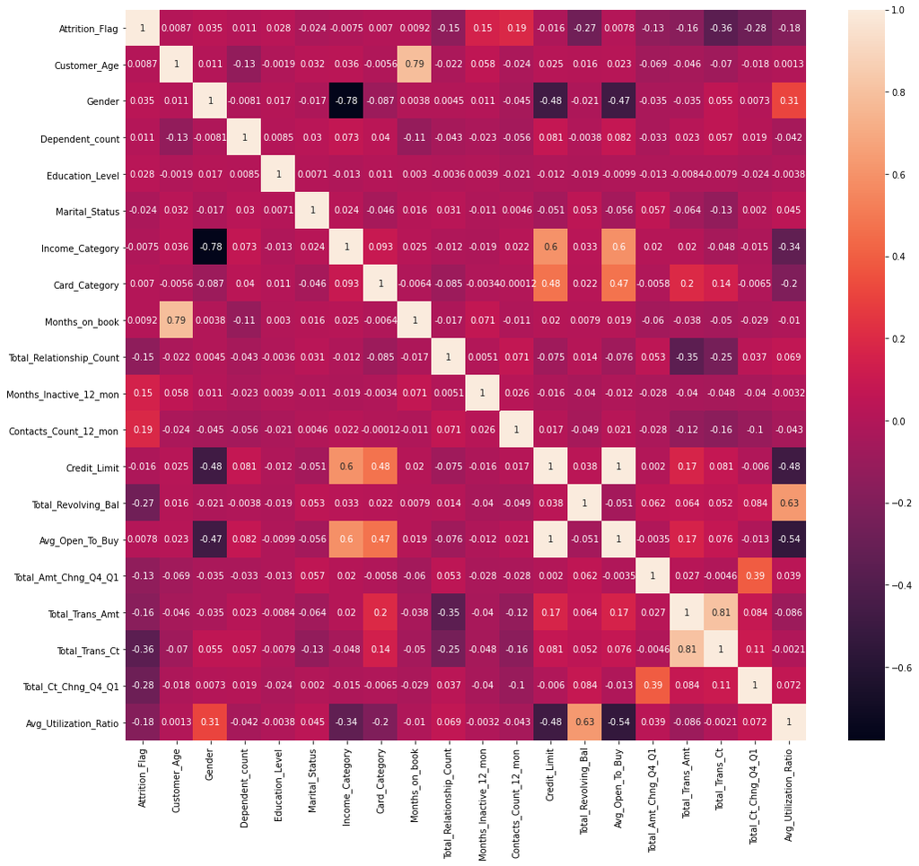

```python
plt.figure(figsize=(17, 15))
sns.heatmap(data=df.corr(), annot=True)
```

As we can see, the same variables from the VIF analysis that we noticed were very correlated with other variables are indeed reflected in the heatmap, but now on a one-on-one interaction each. Below is a list of the major "red flags" for us (so to speak) and the other variables they show correlations with:

- `Customer_Age`, `Months_on_book`
- `Credit_Limit`, `Gender`, `Income_Category`, `Card_Category`, `Avg_Open_To_Buy`, and `Avg_Utilization_Ratio`
- `Total_Revolving_Bal`, `Avg_Utilization_Ratio`
- `Total_Trans_Ct`, `Total_Trans_Amt`

Logically, there do seem to be links between these variables. For example, the older a customer is, the more likely they'll have an open account with the same bank for longer. Another example is that the total transaction amount goes up with the total transaction count.

However, having multiple such variables could pose a problem in training our machine learning model. We'll try to either get rid of them or convert them into more useful values in the **Feature Engineering** part of **5. Machine Learning**.

# 5. Machine Learning

With all the analysis we've done so far, we've been able to derive some degree of statistics-based human judgement as to how the variables we have interact with each other.

The goal for us now is to create a machine learning model to learn to take in several input features about a customer and predict whether that customer is likely to attrite or not.

### Feature Engineering

Before that, however, let's act on the insights we've gained from **4. Exploratory Data Analysis**. We've made some observations in our initial basic exploration, and we've noticed some features contribute to multicollinearity. Let's use that understanding to transform our feature set before we feed it into a model we think will work well here.

Here's a little checklist of things we can modify about our data:

1. Drop `Months_on_book`. *Reason: peculiar distribution of data as well as heavy contribution to multicollinearity.*
2. Drop `Avg_Utilization_Ratio`. *Reason: heavy contribution to multicollinearity with several variables, and not much correlation with* `Attrition_Flag`.
3. Drop `Avg_Open_To_Buy`. *Reason: heavy contribution to multicollinearity with several variables, and not much correlation with* `Attrition_Flag`.
4. Drop `Income_Category`. *Reason: heavy contribution to multicollinearity without much impact on* `Attrition_Flag`.
5. Drop `Credit_Limit`. *Reason: heavy contribution to multicollinearity without much impact on* `Attrition_Flag`.
6. Drop `Customer_Age`. *Reason: some contribution to multicollinearity without much impact on* `Attrition_Flag`.
7. Divide `Total_Trans_Amt` by `Total_Trans_Ct` to get `Amt_Per_Trans`, and then drop `Total_Trans_Amt` and `Total_Trans_Ct`. *Reason: an average amount per transaction is a better indicator of the customer's interest in continuing to use their credit card than two aggregate values which each contribute to multicollinearity.*

```python
df["Amt_Per_Trans"] = df["Total_Trans_Amt"]/df["Total_Trans_Ct"]
df.drop(columns=["Total_Trans_Ct", "Total_Trans_Amt", "Months_on_book", "Avg_Utilization_Ratio", "Customer_Age", "Avg_Open_To_Buy", "Income_Category", "Credit_Limit"], inplace=True)
df.head()
```

|  | Attrition_Flag | Gender | Dependent_count | Education_Level | Marital_Status | Card_Category | Total_Relationship_Count | Months_Inactive_12_mon | Contacts_Count_12_mon | Total_Revolving_Bal | Total_Amt_Chng_Q4_Q1 | Total_Ct_Chng_Q4_Q1 | Amt_Per_Trans |
| --- | --- | --- | --- | --- | --- | --- | --- | --- | --- | --- | --- | --- | --- |
| 0 | 0 | 1 | 3 | 2 | 3 | 1 | 5 | 1 | 3 | 777 | 1.335 | 1.625 | 27.238095 |
| 1 | 0 | 2 | 5 | 4 | 1 | 1 | 6 | 1 | 2 | 864 | 1.541 | 3.714 | 39.121212 |
| 2 | 0 | 1 | 3 | 4 | 3 | 1 | 4 | 1 | 0 | 0 | 2.594 | 2.333 | 94.350000 |
| 4 | 0 | 1 | 3 | 1 | 3 | 1 | 5 | 1 | 0 | 0 | 2.175 | 2.500 | 29.142857 |
| 5 | 0 | 1 | 2 | 4 | 3 | 1 | 3 | 1 | 2 | 1247 | 1.376 | 0.846 | 45.333333 |

```python
df.shape
```

```
(7081, 13)
```

As a certain legendary CMSC320 professor once said to his Spring 2021 class, it's important to allow the next stage of the data science pipeline to inform the previous stage, so that we optimize our approach over time. In lieu of that, let's check if we've combatted the issue of multicollinearity in our variables.

```python
vif_independent_vars = df.iloc[:, 1:13]
vif_data = pd.DataFrame()
vif_data["Feature"] = vif_independent_vars.columns
vif_data["VIF"] = [variance_inflation_factor(vif_independent_vars.values, i) for i in range(len(vif_independent_vars.columns))]
vif_data
```

|  | Feature | VIF |
| --- | --- | --- |
| 0 | Gender | 8.289735 |
| 1 | Dependent_count | 4.105852 |
| 2 | Education_Level | 5.413386 |
| 3 | Marital_Status | 5.506824 |
| 4 | Card_Category | 10.793617 |
| 5 | Total_Relationship_Count | 7.164807 |
| 6 | Months_Inactive_12_mon | 6.038506 |
| 7 | Contacts_Count_12_mon | 5.505576 |
| 8 | Total_Revolving_Bal | 3.063531 |
| 9 | Total_Amt_Chng_Q4_Q1 | 14.125928 |
| 10 | Total_Ct_Chng_Q4_Q1 | 11.430219 |
| 11 | Amt_Per_Trans | 6.912923 |

The VIF values are looking much better, and much closer to our desired range! It's time to finally move onto the next step.

### Data Split and Scaling

In ML, there's a four-way division of the data: the features-label split and the training-testing split.

The features-label split allows us to explicitly distinguish the target variable, or `y` (in our case, the label, which is `Attrition_Flag`), from the remaining independent variables, or `x` (everything we've been left with after our feature engineering step).

Let's carry define our target variable.

```python
y = df["Attrition_Flag"]
y.head()
```

```
0    0
1    0
2    0
4    0
5    0
Name: Attrition_Flag, dtype: int64
```

Now, because the values we have in each column of our feature set vary so widely across their minimum and maximum values, it's a good idea to apply some sort of scaling (or normalization, in a sense) to the data so that the machine learning model can converge more efficiently.

We'll scale the feature set in this manner before assigning it to `x`.

```python
from sklearn.preprocessing import MinMaxScaler
from sklearn.preprocessing import StandardScaler
scaler = MinMaxScaler()
x = scaler.fit_transform(df.iloc[:, 1:13])
x
```

```
array([[0.        , 0.6       , 0.2       , ..., 0.39299382, 0.43753366,
        0.04735408],
       [1.        , 1.        , 0.6       , ..., 0.45363556, 1.        ,
        0.11682355],
       [0.        , 0.6       , 0.6       , ..., 0.76361495, 0.6281637 ,
        0.43969459],
       ...,
       [0.        , 0.4       , 0.6       , ..., 0.20694731, 0.23074852,
        0.66139784],
       [1.        , 0.2       , 0.2       , ..., 0.24109508, 0.22024771,
        0.89081589],
       [1.        , 0.4       , 0.6       , ..., 0.20694731, 0.17474421,
        0.87466574]])
```

And now, the second two-way split of the data: the training-testing split. This is important because we want to distinguish the *seen* data from the *unseen* data. This means that the machine learning model will attempt to "converge", or reach an "understanding" (optimal configuration of parameters), over the *seen* data, or the training set.

In essence, it uses the training set to try to learn what makes a customer attrite.

For us to gauge how well it has trained itself, we can assess its performance on the *unseen* data, or testing set, and make use of some common performance metrics to evaluate it.

We'll go with the common training:testing set ratio of 80:20, and shuffle the data while we're at it.

```python
from sklearn.model_selection import train_test_split
x_train, x_test, y_train, y_test = train_test_split(x, y, shuffle=True, test_size=0.2)
```

### Model Selection and Training

It's time to select our model! Let's examine the problem and the data we have in the context of picking out an appropriate ML model to use in this scenario.

- We have multiple input features, but not a massive number of them
- Our label is binary (either `0` for existing customers or `1` for attrited ones)
- We don't have an abnormally large number of rows

This sounds like a job for a logistic regression model! After all, it takes in multiple inputs, weights each of them and adds an intercept value (bias), and compresses its output into a range between 0 and 1 that we can round to check against our binary output labels. It also uses binary cross entropy (log loss) in its parameter optimization as it updates its weights and biases to converge and make reliable predictions.

```python
from sklearn.linear_model import LogisticRegression
from sklearn.metrics import accuracy_score
from sklearn.metrics import recall_score
from sklearn.metrics import precision_score

model = LogisticRegression(solver="liblinear", penalty="l2")
```

```python
train_predictions = model.fit(x_train, y_train)
```

### Testing and Performance Evaluation

```python
test_predictions = model.predict(x_test)
```

```python
accuracy_score(y_test, test_predictions)
```

```
0.8673253352152435
```

```python
precision_score(y_test, test_predictions)
```

```
0.7848101265822784
```

```python
recall_score(y_test, test_predictions)
```

```
0.26609442060085836
```

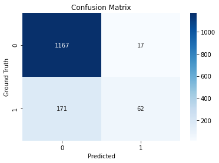

```python
from sklearn.metrics import confusion_matrix

cm = confusion_matrix(y_test, test_predictions)
sns.heatmap(cm, annot=True, fmt="d", cmap='Blues')
plt.ylabel("Ground Truth")
plt.xlabel("Predicted")
plt.title("Confusion Matrix")
```

```python
tp, fp, fn, tp = cm.ravel()
```

```python
# %%shell
!jupyter nbconvert --to html /content/CMSC320_Final_Project_BankChurners.ipynb
```